# Problems with MFT in eBHM + Moving beyond MFT

Akshay Shankar

2022-11-28

# eBHM - Mean Field

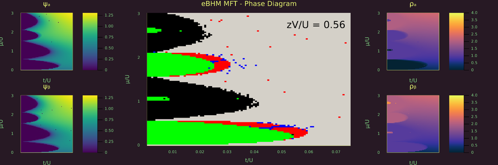

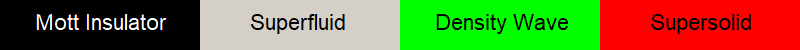

# Algorithm

Self-consistency loop:
$$H \equiv
H\{\psi_i, \rho_i\} \hspace{1cm}\forall i \in \text{unit cell}$$
$$H \cdot|\Psi_{gs}\rangle = E_{gs} \cdot
|\Psi_{gs}\rangle$$
$$\psi_i = \langle
\Psi_{gs} | \hat{a}_i | \Psi_{gs} \rangle \hspace{1cm} \rho_i = \langle
\Psi_{gs} | \hat{n}_i | \Psi_{gs} \rangle$$

Recast in terms of a multi-variate function:

$$f(\{\psi_i, \rho_i\}) \rightarrow
\text{Diagonalize } H\{\psi_i, \rho_i\} \rightarrow \text{Evaluate
}\Psi_{gs} \text{ expectation values} \rightarrow \{\psi_i',
\rho_i'\}$$

Self consistency $\equiv$ Find fixed point of the function.

$$f(\{\psi_i^*, \rho_i^*\}) = \{\psi_i^*,
\rho_i^*\}$$

# Naive attempt at a solution

Given a function $f(x)$, find a fixed point $x^*$ such that $f(x^*) = x^*$.

$$f(x^{(0)}) = x^{(1)}$$
$$f(x^{(1)}) = x^{(2)}$$
$$\vdots$$
$$f(x^{(n)}) = x^{*}$$

Repeatedly apply $f$ on an initial guess $x^{(0)}$ till convergence; (a.k.a fixed point iteration)

$$f(f(f(...f(x)))) \rightarrow
x^*$$

Seems easy enough?

# Problem 1: No convergence

Manifests as 2-cycles, like so:

$$f(\{\psi_A, \psi_B, \rho_A, \rho_B\}) =
\{\psi_A', \psi_B', \rho_A', \rho_B'\}$$
$$f(\{\psi_A', \psi_B', \rho_A',
\rho_B'\}) = \{\psi_A, \psi_B, \rho_A, \rho_B\}$$

[figure not shown]

Exploit patterns in the 2-cycle to guess the fixed point.

Try a different initial guess.

# Problem 2: Sub-linear convergence

Deceptively similar to a 2-cycle in short iterations:

$$f(\{\psi_A, \psi_B, \rho_A, \rho_B\})
\approx \{\psi_A', \psi_B', \rho_A', \rho_B'\}$$
$$f(\{\psi_A', \psi_B', \rho_A',
\rho_B'\}) \approx \{\psi_A, \psi_B, \rho_A, \rho_B\}$$

[figure not shown]

Relative error with the actual value scales sub-linearly with the number of iterations.
$$\underbrace{f(f(f(...f(\{\psi_A, \psi_B, \rho_A,
\rho_B\}))))}_{\text{a looooot of times}} \rightarrow \{\psi_A^*,
\psi_B^*, \rho_A^*, \rho_B^*\}$$

# Solution

Use more sophisticated solvers (Anderson/Nesterov acceleration).

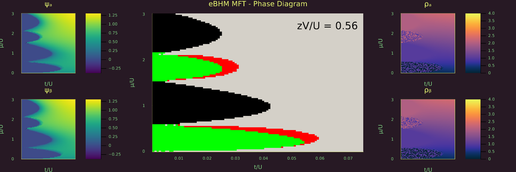

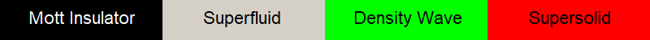

# Not so fast!

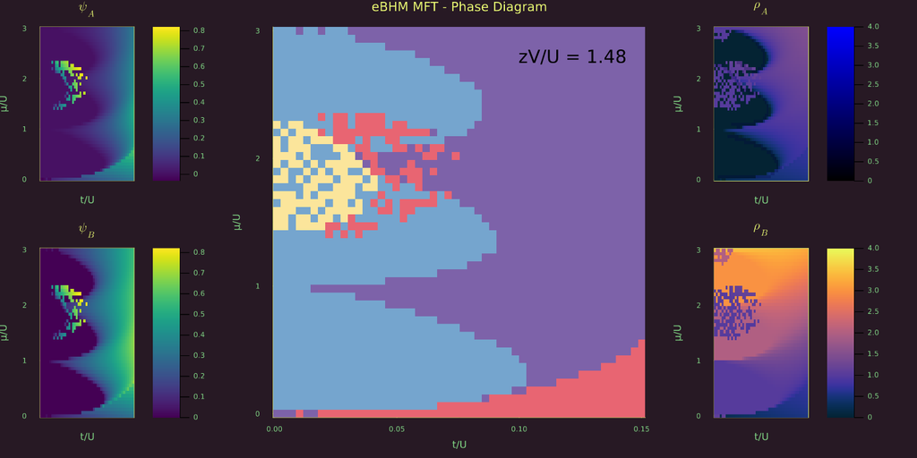

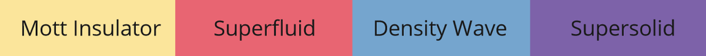

Strange artefacts for larger $zV/U$.

# Problem 3: Multiple fixed points (a.k.a. local minima)

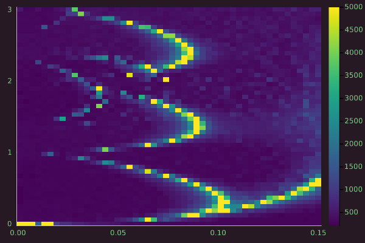

- Plot heatmap of number of iterations required to converge.
- Indicates that the artefacts are not convergence issues, but rather local minima.

# Solution

- Start with a grid of $N$ initial guesses $\{\psi_i, \rho_i\}_k$
- Converge to fixed points $\{\psi_i', \rho_i'\}_k$
- $\{\psi_i^*, \rho_i^*\} = \underset{1 \leq k \leq N}{\text{argmin }} E_{gs}\{\psi_i', \rho_i'\}_k$

[figure not shown]

# Triangular lattice

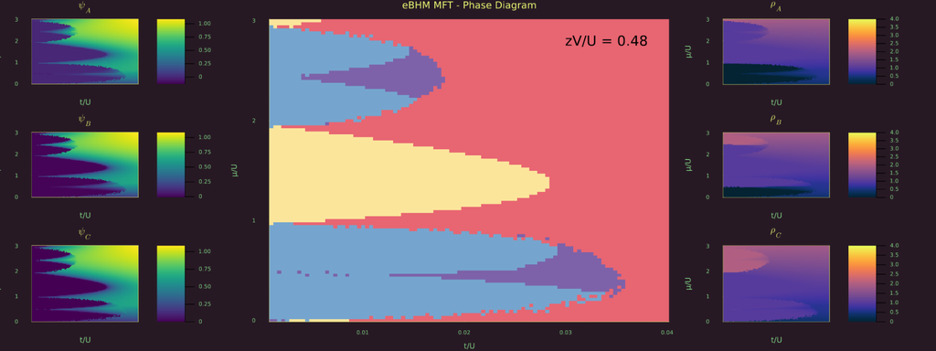

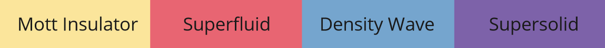

Possible line of inquiry: Is it easier to observe SS in triangular lattice?

# Extracting phase boundaries

Naive method: Compute for a grid of parameter values and find the points where the order parameter jumps.

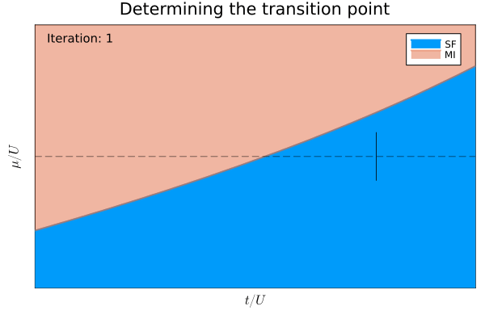

- Precise method: Use a bisection algorithm. Precision scales as $~2^{-n}$ for $n$ iterations.

# Result: Square lattice

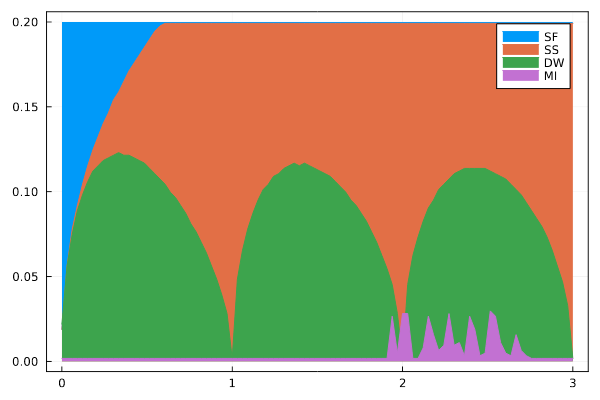

Cleaner phase boundaries with arbitrary precision.

# Neural Network variational ansatz

Ansatz for the wave-function: $\Psi = \sum_{n} \Psi(n) |n\rangle$ such that $\Psi(n)$ is captured by a neural network.

[figure not shown]

Train the network weights to minimize $\langle \hat{H} \rangle$.

# Problem 1: …local minima

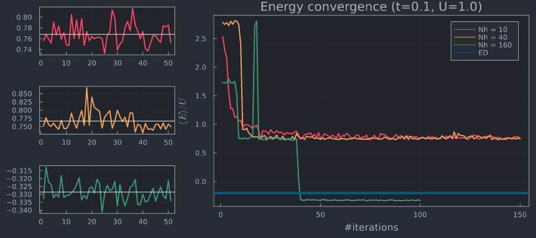

Requires better gradient descent algorithm. Not working on this at the moment.

# Quantum Monte Carlo: Stochastic Series Expansion (SSE)

Start with a spin-1/2 heisenberg model;

$$H = -J \sum_{\langle i, j\rangle}
\vec{S_i} \cdot \vec{S_j}$$
$$H =
-J \sum_{\langle b \rangle} \frac{1}{2} (S_{i(b)}^+S_{j(b)}^- +
S_{j(b)}^+S_{i(b)}^-) + S_{i(b)}^z S_{j(b)}^z$$
$$H = -J\sum_b \underbrace{H_{b,
1}}_{\text{off-diagonal}} + \underbrace{H_{b,
2}}_{\text{diagonal}}$$

# Compute the partition function

$$Z = Tr(\exp(-\beta H))$$
$$Z = Tr\left[ \sum_{n=0}^{\infty}
\frac{(-\beta)^n}{n!} \cdot \left(\sum_b H_{b, 1} + H_{b, 2}\right)^n
\right ]$$
$$Z =
\sum_{n=0}^{\infty} \frac{(-\beta)^n}{n!} \cdot
\sum_{|\alpha\rangle}\sum_{S_n} \langle \alpha | \left (\prod_{\{b, i\}
\in S_n} H_{b, i} \right) | \alpha \rangle = \sum_{C_i \
\in\ \mathcal{C}} w(C_i)$$
Define configuration of the system, $C_i \equiv [|\alpha\rangle, S_n]$.

Sample these $C_i \in \mathcal{C}$ ergodically to compute diagonal observables.

# Expansion truncation

$$\langle E \rangle = -\frac{\langle n
\rangle}{\beta} \hspace{0.5cm} \text{and} \hspace{0.5cm} C_v = \langle
n^2 \rangle - \langle n \rangle^2 - \langle n \rangle$$

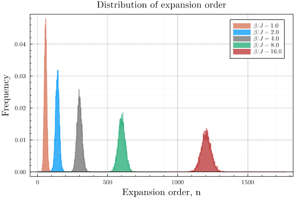

We can maintain a cut-off $n_{max}$ dynamically as the simulation progresses and introduce negligible error.

# Mapping to eBHM

XXZ spin-$1/2$ model:

$$H = \frac{J_x}{2} \sum_{\langle i, j
\rangle} (S_{i}^+S_{j}^- + S_{j}^+S_{i}^-) + J_z\sum_{\langle i, j
\rangle} S_{i}^z S_{j}^z + h_z \sum_i S_i^z$$
eBHM w/ hard-core bosons:

$$H = -t\sum_{\langle i, j \rangle}
(a_i^{\dagger} a_j + a_j^{\dagger}a_i) + V\sum_{\langle i, j\rangle} n_i
n_j - \mu \sum_i n_i$$

Map the operators like so:
$$S_i^+ \equiv
a_i^{\dagger} \hspace{1cm} S_i^z \equiv (n_i - 1/2)$$
Analogous quantities:
$$t \equiv \frac{J_x}{2}
\hspace{1cm} V \equiv J_z \hspace{1cm} \mu = J_z - h_z$$

# Finite-size scaling effects

$$Q(t, L) = L^{\zeta/\nu} \cdot
g(tL^{1/\nu}) \hspace{2cm} t = (T - T_c)/T_c$$

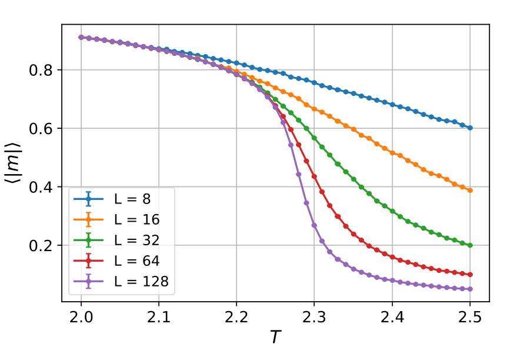

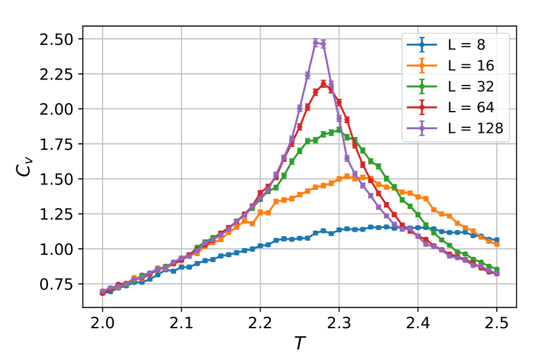

Results for the 2D Ising model

# Obtaining the phase boundary

Binder’s cumulant:
$$U_L = 1 -
\frac{\langle m^4 \rangle_L}{3\langle m^2 \rangle^2_L} \hspace{1cm}
\text{and} \hspace{1cm} U_L(t=0) = U_{L'}(t=0) \hspace{0.2cm} \
\forall \ L, L'.$$

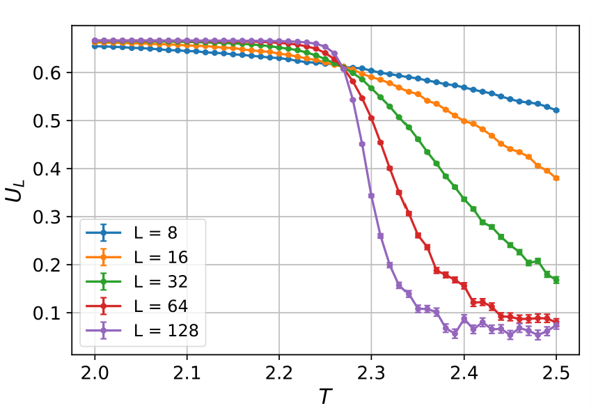

Plot binder’s cumulant of the order parameter for different lattice sizes and find the intersection point.

# Results for heisenberg model

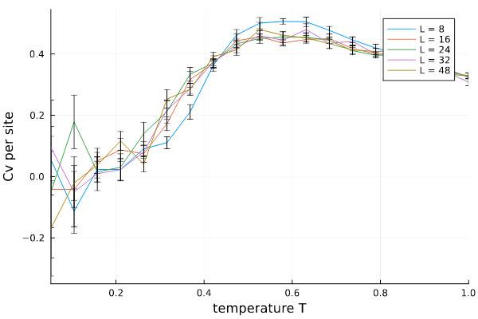

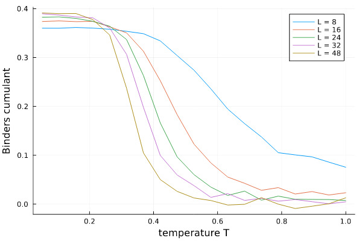

- Transition point does not seem to match?
- Finite-size scaling not discernible visually?

[figure not shown]

# Supplementary: Convergence of MFT in BHM

[figure not shown]

Convergence is monotonic!

A single iteration with an initial guess of $~10^{-6}$ is sufficient to determine the phase.